# Extract and Visualise the Sub-network Containing the Highest In- and Out-degree Individuals - crit

This treats “Poster-Commenter” networks. The assumption of the following that a tie between individuals is defined by a comment on a post. This is a directed tie from the commenter to the poster. A tie is assumed if there are 1 or more comments and ties are **not** weighted by the number of comments.

```
## Loaded data. Created by: Poster-Commenter Created on: Tue Oct 29 18:37:22 2013
```

```
##  Network attributes:
##   vertices = 4688
##   directed = TRUE
##   hyper = FALSE
##   loops = FALSE
##   multiple = FALSE
##   bipartite = FALSE
##   total edges= 2446
##     missing edges= 0
##     non-missing edges= 2446
##
##  Vertex attribute names:
##     anon_user_id role vertex.names
```

## Preliminaries - identify the highest in/out degree individuals

```r
odeg <- degree(net1, cmode = "outdegree")
ideg <- degree(net1, cmode = "indegree")
# get indexes to nodes and filter for tiny quantile (top.quantile) not
# happy with this method, what is the best cut off to give comparable
# views between courses?
ocentile <- quantile(odeg, 1 - top.quantile)
icentile <- quantile(ideg, 1 - top.quantile)
oindex <- which(odeg >= ocentile)
iindex <- which(ideg >= icentile)
odeg <- odeg[oindex]
ideg <- ideg[iindex]
# order
oorder <- order(odeg, decreasing = T)
iorder <- order(ideg, decreasing = T)
odeg <- odeg[oorder]
ideg <- ideg[iorder]
oindex <- oindex[oorder]
iindex <- iindex[iorder]
# combine forum_user_id and role from nodes with degree.
vroles <- net1 %v% "role"
vnames <- net1 %v% "vertex.names"
outdegree.df <- cbind(forum_user_id = vnames[oindex], role = vroles[oindex],
    out.degree = odeg, match.in = oindex %in% iindex)
indegree.df <- cbind(forum_user_id = vnames[iindex], role = vroles[iindex],
    in.degree = ideg, match.out = iindex %in% oindex)
```

**People with highest 0.25% Quantile Out-degree**

| forum_user_id | role | out.degree | match.in |
| --- | --- | --- | --- |
| e6fd6651dc1b0c116f89c27ab98119b83a35399c | 4 | 62 | TRUE |
| 309a07aa2693d34d4db58b57d7715ae197361bdb | 2 | 19 | TRUE |
| d0c465a8b80c50fc44ebeac6bf07ae0eba94611c | 2 | 19 | FALSE |
| eefa126054f6038b00928491ef4e98d5c22d9de9 | 4 | 18 | FALSE |
| 9b8eb6ad9887ea73b08c98f43aace84d20f6b8a7 | 4 | 16 | FALSE |
| 8bbb94a34cde0dbe209625f1405854dbeba6c8cd | 4 | 15 | FALSE |
| e65807e299412ce8a15015974703b083cf5246eb | 4 | 15 | FALSE |
| d57c449fcc03e0edb58c3947a36e1dad7a63eb04 | 4 | 14 | FALSE |
| 1a2f2629bf47b6295e7f00b2cb1d9687cbbaae41 | 4 | 13 | FALSE |
| 6f71d66a5283076f24235fb3b2b01c952781dad2 | 4 | 12 | FALSE |
| d0d3194181c719936733d963edddf416f4229d81 | 4 | 12 | FALSE |
| 3d53d24c860cd178fc3fecf3c415b99fbfa50511 | 4 | 12 | FALSE |
| e4f640e526ab9e6a25e97e33b8ecf5421ce142fd | 4 | 12 | TRUE |

**People with Highest 0.25% Quantile In-degree**

| forum_user_id | role | in.degree | match.out |
| --- | --- | --- | --- |
| b5b9197fc7b9752fefff9da61e6edfab94f6f704 | 4 | 53 | FALSE |
| a8ff42a44421ce5d8ddaca22920a6bc7320ce728 | 4 | 36 | FALSE |
| e6fd6651dc1b0c116f89c27ab98119b83a35399c | 4 | 29 | TRUE |
| b2eb7523b721ec8a981e4e62e46d1987f4f28261 | 4 | 29 | FALSE |
| 4f38a92c914e99defc3900b463a5d9065a482f14 | 3 | 28 | FALSE |
| b37cdf01402e48b017f876ab016a1cc1676633e8 | 2 | 27 | FALSE |
| 5ee9c519d3f791059a0a23b4bdfee1e6b3dcbc16 | 4 | 26 | FALSE |
| 309a07aa2693d34d4db58b57d7715ae197361bdb | 2 | 20 | TRUE |
| efaa8ea0b66f404ce7b585a61a90fb317eaad4f0 | 2 | 20 | FALSE |
| e4f640e526ab9e6a25e97e33b8ecf5421ce142fd | 4 | 17 | TRUE |
| 23f47f66635bc6276560a0b1082085abcb5d86f0 | 2 | 14 | FALSE |
| f0b6483ef3d92d21311694c87ef041243a703145 | 4 | 14 | FALSE |

*Match.in/out shows where the same person appears in the other list.*

## Extract the Subnet

This includes all of the people above and any other person who they commented on or who commented on them. Individuals with 1 or only a few ties are not from the above sets but have been included as due to a tie with at least 1 member of these lists.

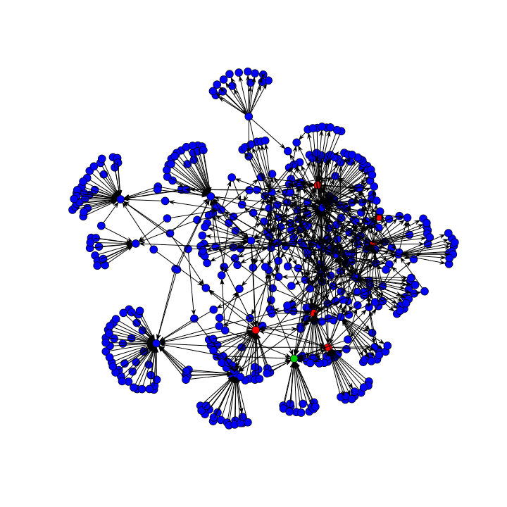

```r
# obtain the subgraph containing these nodes and linked edges.  NB:
# get.neighbourhood is not vectorised!
o.connected <- c(oindex, unlist(sapply(oindex, function(x) {
    get.neighborhood(net1, x, type = "combined")
})))
i.connected <- c(iindex, unlist(sapply(iindex, function(x) {
    get.neighborhood(net1, x, type = "combined")
})))
connected <- unique(c(o.connected, i.connected))
top.subnet <- net1 %s% connected
vertex.col <- as.numeric(top.subnet %v% "role")
# we could colourise according to whether people were in the top set or
# only connected to them using
# vertex.col<-as.numeric(connected[order(connected)] %in%
# c(oindex,iindex))+1 #order needed!
plot(top.subnet, arrowhead.cex = 0.7, edge.lwd = 0.4, vertex.col = vertex.col,
    vertices.last = FALSE)
```

There are 497 individuals in the diagram.

In practice, choosing selecting more high degree people selected, say 0.5% vs 0.25%, does not make much difference to the appearance of the subnet if there are 1 or 2 very high degree individuals.

### The Network of Associates

What does the network look like if we take away the highest degree people and only look at the people they were connected to (who were not already in either list, above).

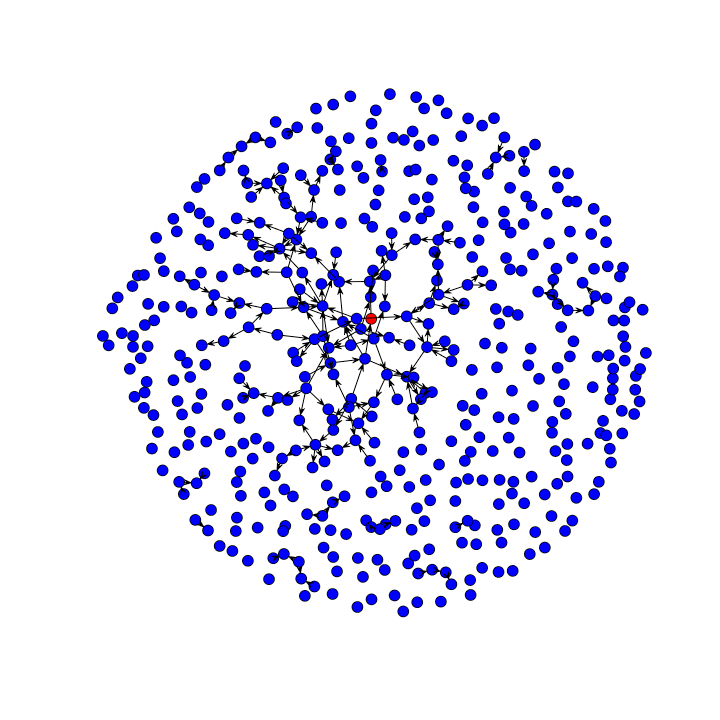

```r
connected.associates <- connected[!connected %in% c(oindex, iindex)]
associates.subnet <- net1 %s% connected.associates
vertex.col <- as.numeric(associates.subnet %v% "role")
# we could colourise according to whether people were in the top set or
# only connected to them using
# vertex.col<-as.numeric(connected[order(connected)] %in%
# c(oindex,iindex))+1 #order needed!
plot(associates.subnet, arrowhead.cex = 0.7, edge.lwd = 0.4, vertex.col = vertex.col,
    vertices.last = FALSE)
```

There are 475 individuals in the diagram.

### Compare to a randomly selected group of people numbering the same as the “associates”

*The number of people is only approximately the same because 475 are drawn with replacement and then unique people plotted. Should be good enough for a qualitative comparison, which is what is intended, and the fraction of the people available is small.*

Beware: for a better comparison, we should randomly select people (posters) who have been commented on, or who have commented.

[figure not shown]

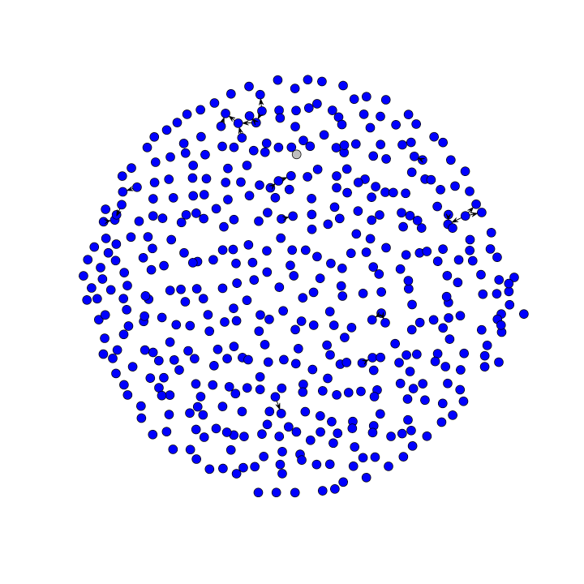

```r
connected.random <- unique(round(runif(length(connected.associates), 1, network.size(net1))))
random.subnet <- net1 %s% connected.random
vertex.col <- as.numeric(random.subnet %v% "role")
plot(random.subnet, arrowhead.cex = 0.7, edge.lwd = 0.4, vertex.col = vertex.col,
    vertices.last = FALSE)
```

## Extract the subnet for only the highest degree (in and out) person and their ties.

This will select 1 or 2 people and their ties, depending on whether the same individual has the highest in and out degrees or not.

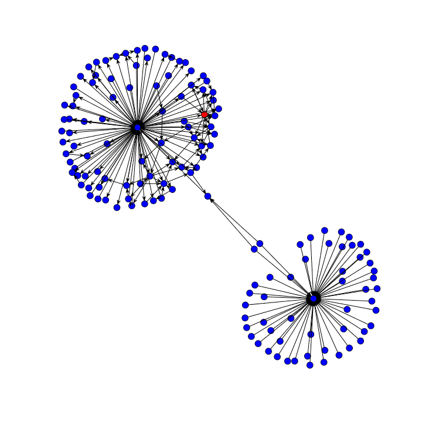

```r
o.connected.1 <- c(oindex[1], get.neighborhood(net1, oindex[1], type = "combined"))
i.connected.1 <- c(iindex[1], get.neighborhood(net1, iindex[1], type = "combined"))
connected.1 <- unique(c(o.connected.1, i.connected.1))
top.1.subnet <- net1 %s% connected.1
vertex.1.col <- as.numeric(top.1.subnet %v% "role")
plot(top.1.subnet, arrowhead.cex = 0.7, edge.lwd = 0.4, vertex.col = vertex.1.col, vertices.last = FALSE)
```

There are 143 individuals in the diagram.

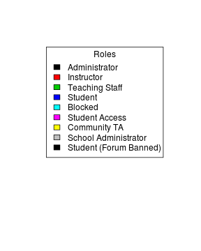

```
## Saved UCINET DL file to: ~/R Projects/Edinburgh MOOC/EdMOOC-SNA/Top Subnets/Degree P-C - crit.dl
```